# Inferring a species tree for the *Anolis distichus* species group with the polymorphism-aware phylogenetic model (PoMo)

Tanner Myers

# `IQ-TREE2`: Polymorphism-aware species tree estimation

An approach that I would argue has been under-used by empirical systematists is the use of polymorphism-aware phylogenetic models. Whereas substitution-model based phylogenetic models only consider mutation to be a source of variation, these models account for incomplete lineage sorting by using within-species variation. To achieve this, instead of providing sequences for each individual, users must define their populations or species *a priori* and generate a “counts” file that represents each site as the number of A’s, T’s, C’s, and G’s present at that site in a given population, like this:

```
                ravitergum      ignigularis
scaffold_1:1    0,0,0,8         4,0,0,4
scaffold_1:3    0,0,0,4         2,0,0,3
```

## Prepare data for PoMo

```bash
#!/usr/bin/env bash
#SBATCH --job-name=brev-stacks
#SBATCH --nodes=1
#SBATCH --ntasks-per-node=1
#SBATCH --cpus-per-task=10
#SBATCH --partition=jro0014_amd
#SBATCH --mem=82gb
#SBATCH --time=48:00:00
#SBATCH --mail-user=tcm0036@auburn.edu
#SBATCH --mail-type=FAIL,END
#SBATCH --error=err.pops_%j
#SBATCH --output=out.pops_%j

source ~/mambaforge/etc/profile.d/conda.sh
conda activate genomics_env

POPMAP=/home/tcm0036/distichus-ddRAD/brevirostris-ms/scripts/bioinformatics/filtered-specimens.txt
CAT_DIR=/scratch/tcm0036/distichus-ddRAD/brevirostris-project/stacks/gstacks/
OUT_DIR=/scratch/tcm0036/distichus-ddRAD/brevirostris-project/stacks/populations/phylo/
LIST=/home/tcm0036/distichus-ddRAD/brevirostris-ms/scripts/bioinformatics/fullmiss90LD_snps.txt

# Run populations to get full RAD tags with invariant sites for white-listed loci (concatenated ML and PoMo tree)
populations -P $CAT_DIR -M $POPMAP -O $OUT_DIR -W $LIST -t 10 --max-obs-het 0.5 --phylip-var-all --vcf-all
```

Using Biopython, we can convert the phylip file to fasta format:

```python
from Bio import AlignIO

AlignIO.convert("/scratch/tcm0036/distichus-ddRAD/brevirostris-project/stacks/populations/phylo/populations.all.phylip",
    "phylip",
    "/scratch/tcm0036/distichus-ddRAD/brevirostris-project/stacks/populations/phylo/pomo/populations.all.phylip.fasta",
    "fasta")
```

```bash
### get sample identifiers from FASTA and their population assignments for changing names in the FASTA
grep ">" populations.all.phylip.fasta | sed 's/>//g' | awk -v "FS=." '{print $1}' > fasta_samples.txt
awk '{print $1, $7}' ~/distichus-ddRAD/brevirostris-ms/sampling-master-detailed.tsv | tail -n297 > fasta_sample_pops.txt
# awk '{print $1}' fasta_sample_pops.txt | diff fasta_samples.txt -
awk '{print $2}' fasta_sample_pops.txt > pops.txt

awk 'FNR==NR {names[++i] = $1; next} /^>/ {print ">" names[++j]; next} 1' pops.txt populations.all.phylip.fasta  > full_miss90_LD_loci.pops.fasta

### use --iupac option to model heterozygous sites encoded as IUPAC codes
FastaToCounts.py --iupac full_miss90LD_loci.pops.fasta full_miss90LD_loci.pops.cf
```

# Run IQ-TREE2 specifying PoMo model

## Determining the virtual population size parameter

```bash
sort /scratch/tcm0036/distichus-ddRAD/brevirostris-project/stacks/populations/phylo/pomo/pops.txt | uniq -c | awk '{print $1}' | awk '{ total += $1; count++ } END { print total/count }'
```

```bash
#! /usr/bin/env bash
#SBATCH --job-name=PoMo
#SBATCH --partition=jro0014_amd
#SBATCH --mem=56G
#SBATCH --time=12:00:00
#SBATCH --error=err.PoMo_%j
#SBATCH --output=out.PoMo_%j

source ~/mambaforge/etc/profile.d/conda.sh
conda activate phyloenv

cd /scratch/tcm0036/distichus-ddRAD/brevirostris-project/phylo/pomo

CF=/scratch/tcm0036/distichus-ddRAD/brevirostris-project/stacks/populations/phylo/pomo/full_miss90LD_loci.pops.cf

### Run IQ-TREE2
iqtree -s $CF -B 1000 -alrt 1000 -nt AUTO -seed 1968 -m GTR+P+N9+G4 -pre PoMo_full_miss90LD_loci
```

Let’s visualize the unrooted PoMo tree (N=9):

```r
library(tidyverse)
library(ape)
library(ggtree)
library(treeio)
```

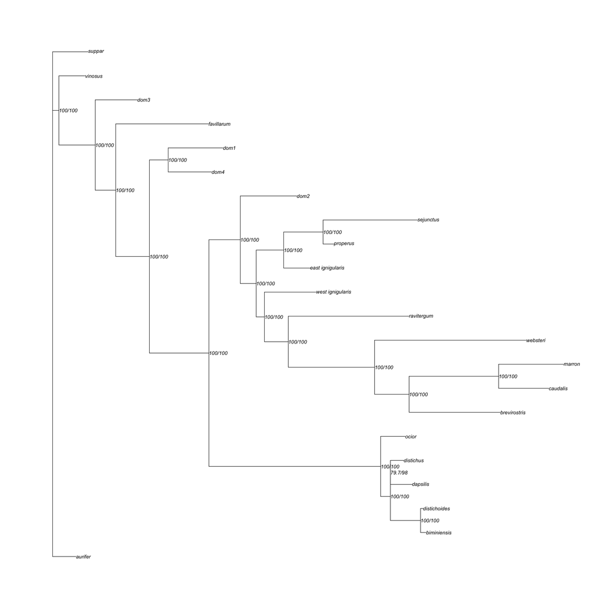

```r
pomo <-read.tree("/Users/tannermyers/Dropbox/Distichus_Project/brevirostris-ms/phylo/iqtree-pomo/PoMo_full_miss90LD_loci.treefile")
plot.phylo(pomo, show.node.label = TRUE, cex = 0.8)
```

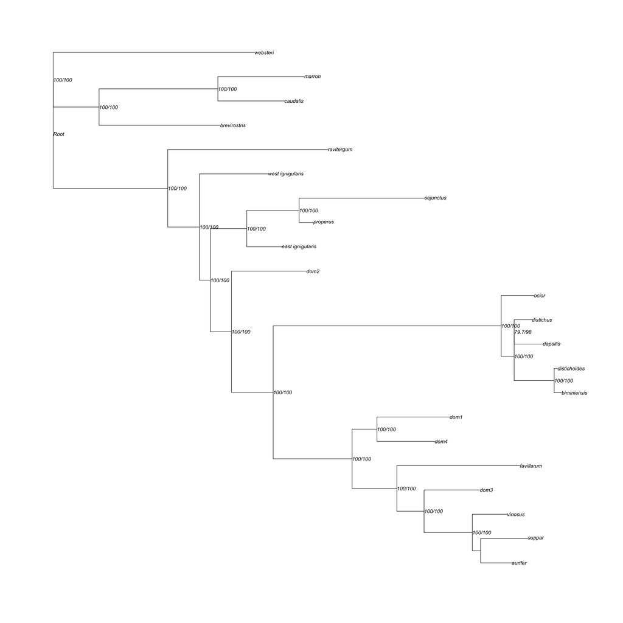

```r
### Root tree using brevirostris clade as outgroup
pomo2 <- root(pomo, outgroup = c('brevirostris', 'caudalis', 'websteri', 'marron'), resolve.root = TRUE)
plot.phylo(pomo2, show.node.label = TRUE, cex = 0.8)
```

```r
pomo2$tip.label
```

```
##  [1] "aurifer"          "biminiensis"      "distichoides"     "dapsilis"
##  [5] "distichus"        "ocior"            "brevirostris"     "caudalis"
##  [9] "marron"           "websteri"         "ravitergum"       "west_ignigularis"
## [13] "east_ignigularis" "properus"         "sejunctus"        "dom2"
## [17] "dom4"             "dom1"             "favillarum"       "dom3"
## [21] "vinosus"          "suppar"
```

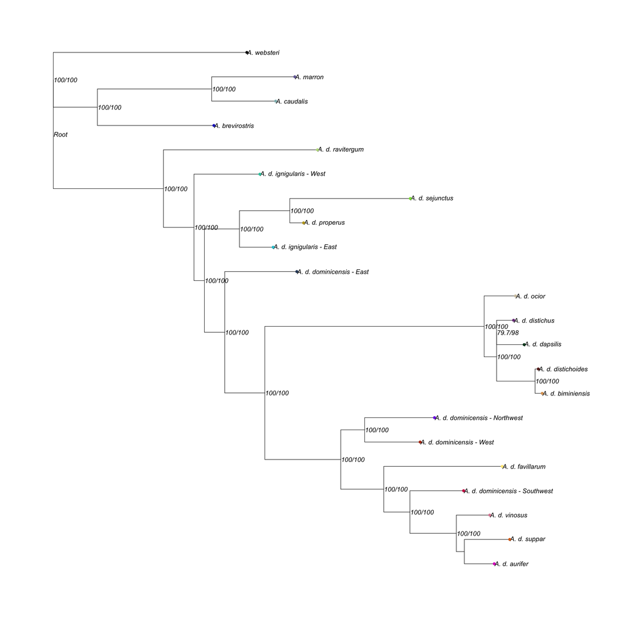

```r
# Reordered to match pomo2$tip.label order
tip_labels <- c("A. d. aurifer", "A. d. biminiensis", "A. d. distichoides", "A. d. dapsilis",
                "A. d. distichus", "A. d. ocior", "A. brevirostris", "A. caudalis",
                "A. marron", "A. websteri", "A. d. ravitergum", "A. d. ignigularis - West",
                "A. d. ignigularis - East", "A. d. properus", "A. d. sejunctus",
                "A. d. dominicensis - East", "A. d. dominicensis - West",
                "A. d. dominicensis - Northwest", "A. d. favillarum",
                "A. d. dominicensis - Southwest", "A. d. vinosus", "A. d. suppar")

# Reordered colors to match
tip_colors <- setNames(c(
        "#DB0CC4", # aurifer
        "#DBA163", # biminiensis
        "#662822", # distichoides
        "#104728", # dapsilis
        "#7B3F8A", # distichus
        "#D1C5AE", # ocior
        "#202AC2", # brevirostris
        "#93BBBD", # caudalis
        "#756CA3", # marron
        "#000000", # websteri
        "#BBDB8B", # ravitergum
        "#30C7AB", # west ignigularis
        "#28C3D1", # east ignigularis
        "#BDA425", # properus
        "#87DB41", # sejunctus
        "#2E4766", # dom2 (East)
        "#B83B15", # dom4 (West)
        "#7C15E6", # dom1 (Northwest)
        "#FFE684", # favillarum
        "#CE0452", # dom3 (Southwest)
        "#DB8CA3", # vinosus
        "#DB6E1B"  # suppar
    ),
        tip_labels
)

# Update tip labels
pomo2$tip.label <- tip_labels


plot.phylo(pomo2, show.node.label = TRUE, label.offset = 0.001)
tiplabels(pch = 16, col = tip_colors)
```

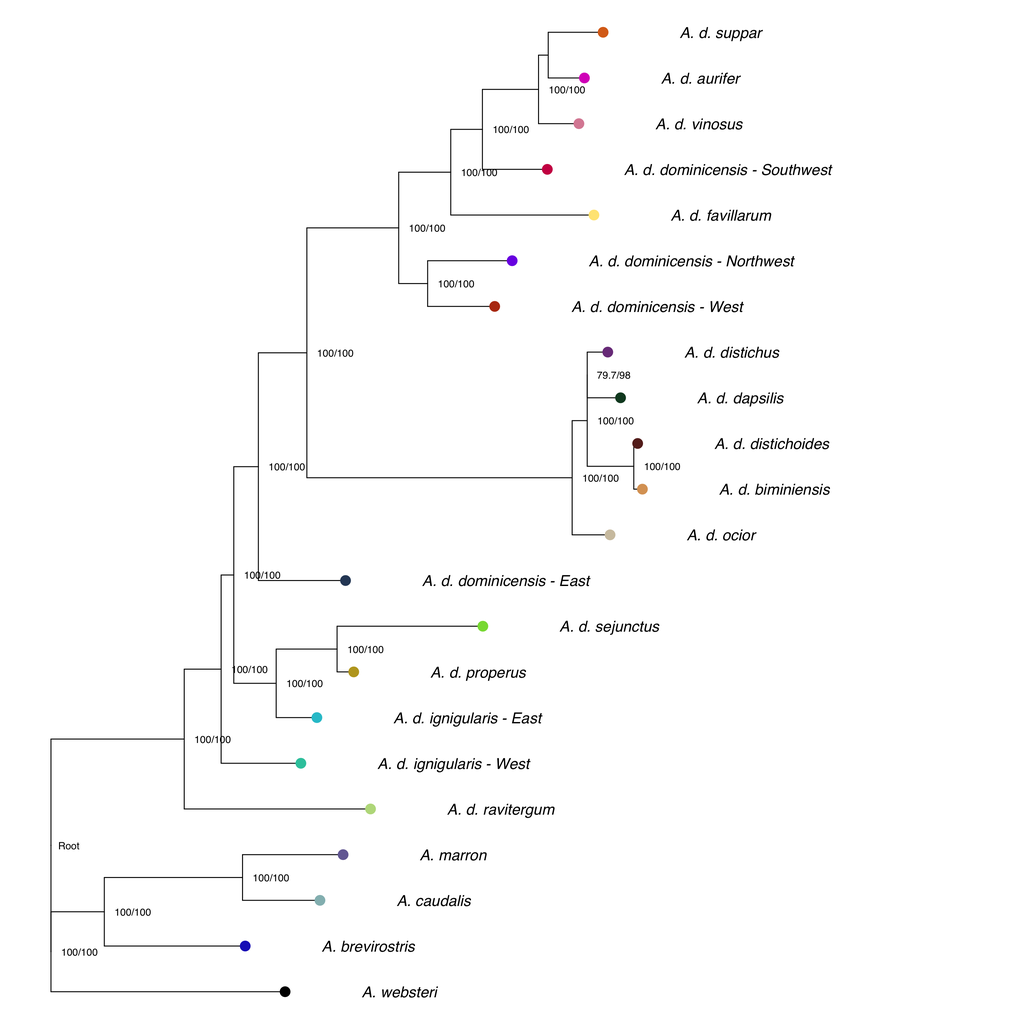

```r
ggtree(pomo2) +
        geom_tiplab(size = 6, offset = 0.2,
                family = "Helvetica", fontface = "italic") +
        geom_nodelab(size = 4, hjust = -0.2) +  # Show node labels
        geom_tippoint(aes(color = label), size = 5) +
        scale_color_manual(values = tip_colors) +
        theme(legend.position = "none",
                axis.line.x = element_blank(),
                axis.text.x = element_blank(),
                axis.ticks.x = element_blank()) +
        hexpand(.3)
```

```r
ggsave("/Users/tannermyers/Dropbox/Distichus_Project/brevirostris-ms/figures/PoMo_species_tree.pdf",
    width = 14, height = 14, dpi = 300)
```